# Администрирование локальных сетей

Лабораторная работа №7

Авдадаев Джамал Геланиевич

Российский университет дружбы народов, Москва, Россия

23 марта 2026

# Цели и задачи работы

## Цель лабораторной работы

Получить навыки работы с физической рабочей областью Packet Tracer и изучить влияние физических параметров среды передачи данных на работу сети.

# Ход выполнения работы

## Переход в физическую рабочую область

- открыт проект предыдущей лабораторной работы
- выполнен переход в Physical Workspace
- городу присвоено имя **Moscow**

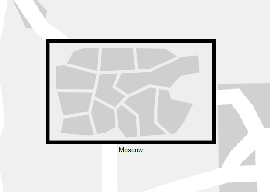

Физическая область — город Moscow

## Настройка зданий

- зданию присвоено имя **Donskaya**
- добавлено новое здание **Pavlovskaya**

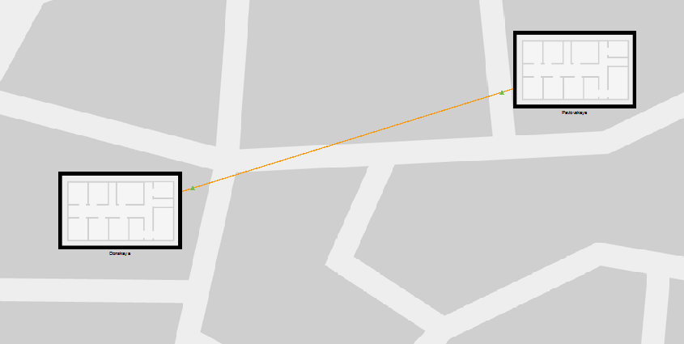

Здания Donskaya и Pavlovskaya

## Размещение серверного помещения

- серверная перемещена в здание Donskaya
- выполнен переход внутрь серверной
- получен доступ к стойкам оборудования

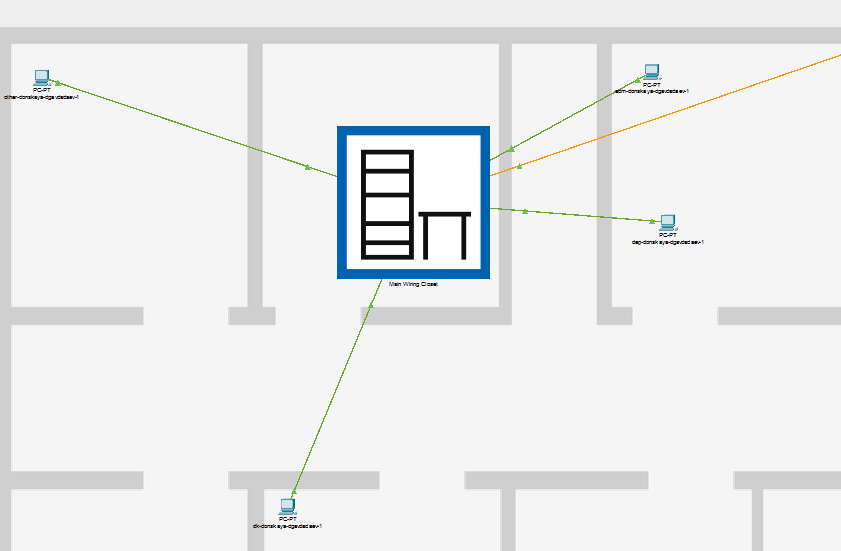

Серверное помещение

## Размещение оборудования

- перемещены устройства в Pavlovskaya:
  - msk-pavlovskaya-sw-1
  - dk-pavlovskaya-1
  - other-pavlovskaya-1

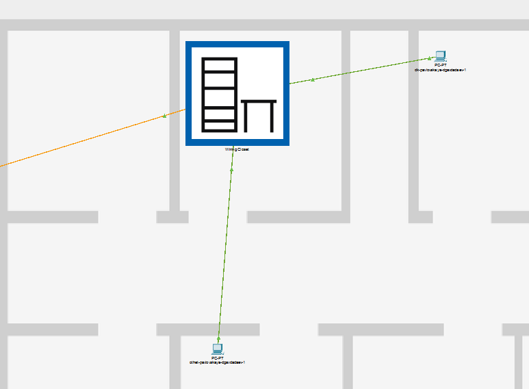

Размещение оборудования

## Проверка соединения

- выполнен ping между коммутаторами
- соединение работает корректно

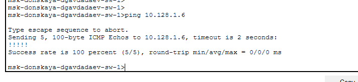

Успешный ping

## Учёт физических параметров

- включена опция **Enable Cable Length Effects**
- активирован учёт длины кабеля

## Увеличение расстояния

- здания размещены на расстоянии >100 м
- длина линии превышает допустимую

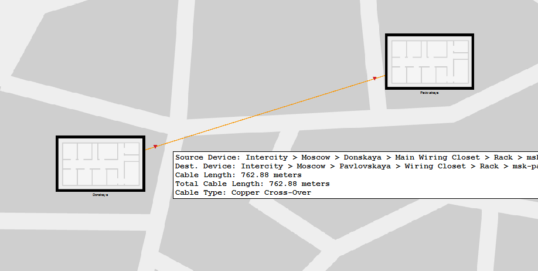

Длина кабеля

## Потеря соединения

- выполнен ping
- соединение отсутствует (100% потерь)

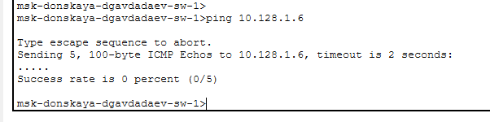

Ошибка соединения

## Добавление повторителей

- добавлены устройства:
  - msk-donskaya-mc-1
  - msk-pavlovskaya-mc-1
- установлены модули для меди и оптики

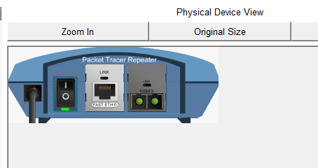

Повторители

## Перемещение повторителя

- msk-pavlovskaya-mc-1 перенесён в Pavlovskaya

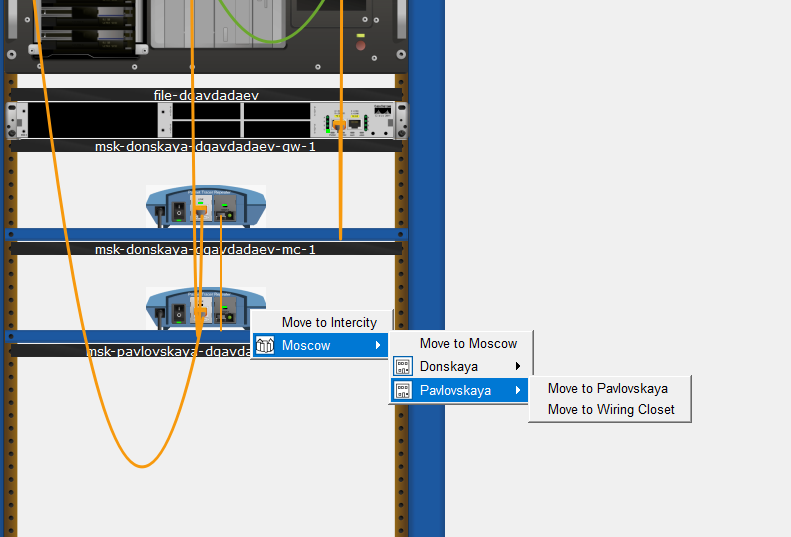

Перемещение устройства

## Новая схема подключения

- витая пара: sw → repeater
- оптоволокно: repeater ↔︎ repeater
- витая пара: repeater → sw

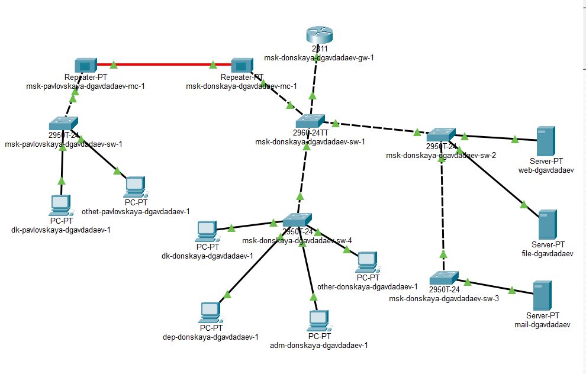

Новая топология

## Проверка соединения

- выполнен повторный ping
- соединение восстановлено

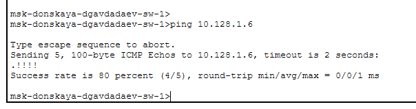

Успешный ping

# Выводы

## Итог лабораторной работы

В ходе выполнения лабораторной работы:

- изучена физическая рабочая область Packet Tracer
- рассмотрено влияние длины кабеля на передачу данных
- выявлена проблема превышения допустимой длины линии
- применены повторители и оптоволоконная линия
- восстановлена работоспособность сети